# Using grouped sequence data with tna

TNA supports the analysis of transition networks constructed from grouped sequence data. Groups can be defined in several ways, but mainly: using a pre-existing grouping variable in the data (e.g., a demographic or experimental condition), or by clustering the sequences themselves based on their similarity. This vignette demonstrates both approaches using the `group_regulation_long` dataset.

First, we load the packages we will use for this example.

```r
library("tna")
library("gt")
```

## Data preparation

We import the data in long format and prepare it for analysis. The `prepare_data()` function converts the long-format event log into wide-format sequences. The unused columns in the dataset are stored in the metadata of `prepared` and we can use them later on.

```r
data("group_regulation_long", package = "tna")
prepared <- prepare_data(group_regulation_long,
                         actor = "Actor",
                         action = "Action",
                         time = "Time")
```

## Groups from a pre-existing variable

When the data contains a grouping variable, we can build separate TNA models for each group directly. Here, the `"Achiever"` column in the metadata splits the sequences into two groups (high vs. low achievers).

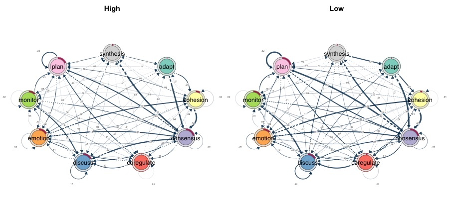

```r
layout(t(1:2))
achievers <- group_tna(prepared, group = "Achiever")
plot(achievers)
```

### Comparing groups

The `plot_compare()` function visualizes the difference network between the two groups. Green edges and donut segments indicate that the first group (High achievers) has higher values, while red indicates the opposite (Low achievers have higher values).

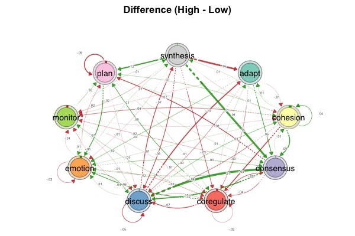

```r
plot_compare(achievers)
```

### Permutation test

The difference network shows how large the differences are, but not whether they exceed what the random assignment of students to the two groups would produce. A permutation test answers that question: it reassigns the sequences to the groups many times and keeps only the edges whose observed difference is unlikely under these reassignments.

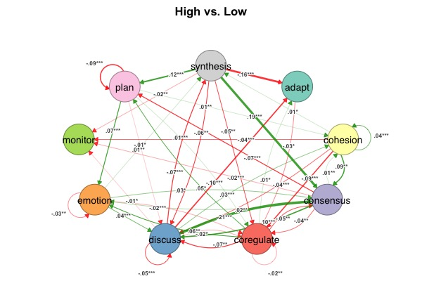

```r
permutation_test_results <- permutation_test(achievers)
plot(permutation_test_results)
```

### Subsequence comparison

We can also compare the frequency of subsequences across groups. Here we look at subsequences of length 3 to 5, keeping only those that appear at least 5 times, and apply FDR correction for multiple comparisons.

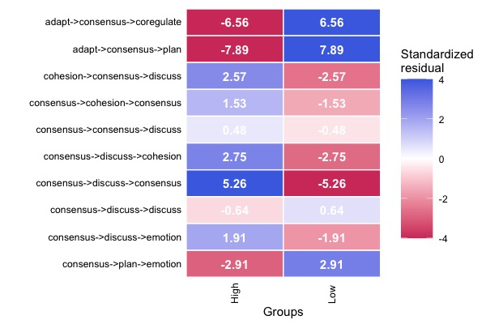

```r
subsequence_comparison  <- compare_sequences(achievers,
                                                  sub = 3:5,
                                                  min_freq = 5,
                                                  adjust = "fdr")
plot(subsequence_comparison, cells = TRUE)
```

## Groups from sequence clustering

When no pre-existing grouping variable is available, we can cluster the sequences based on their pairwise dissimilarity. The `cluster_sequences()` function computes the dissimilarity between every pair of sequences (the Hamming distance by default) and partitions the sequences into `k` clusters (with PAM by default).

```r
clustering_results <- cluster_sequences(prepared, k = 3)
```

To choose an appropriate number of clusters, we can compare the silhouette score for different values of *k*, which the printed clustering reports. Higher silhouette values indicate better-separated clusters.

```r
lapply(2:4, \(k) cluster_sequences(prepared, k = k))
```

```
#> [[1]]
#> Clustering method: pam
#> Number of clusters: 2
#> Silhouette score: 0.1838904
#> Cluster sizes:
#>    1    2
#>  982 1018
#>
#> [[2]]
#> Clustering method: pam
#> Number of clusters: 3
#> Silhouette score: 0.1850873
#> Cluster sizes:
#>   1   2   3
#> 893 494 613
#>
#> [[3]]
#> Clustering method: pam
#> Number of clusters: 4
#> Silhouette score: 0.1327345
#> Cluster sizes:
#>   1   2   3   4
#> 707 506 379 408
```

Once we have chosen *k*, we build the grouped TNA model directly from the clustering result, which carries the sequences and their cluster assignments.

```r
tna_model_clus <- group_tna(clustering_results)
```

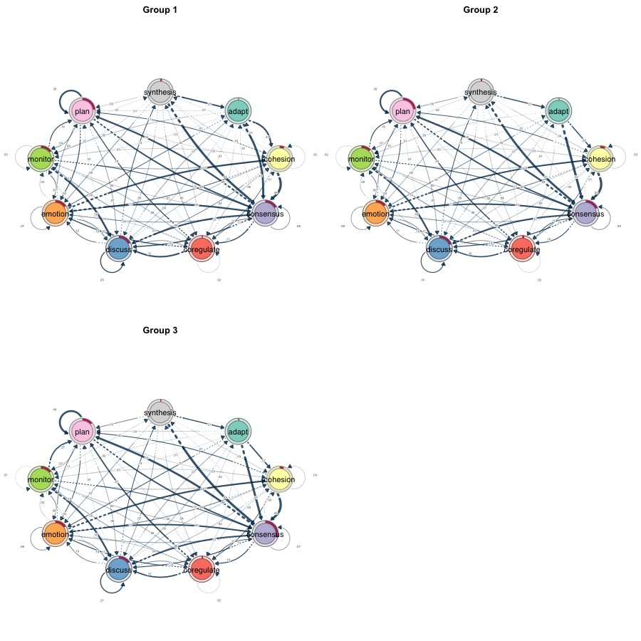

```r
layout(matrix(1:4, byrow = TRUE, ncol = 2))
plot(tna_model_clus)
```

### Summarizing the cluster-specific models

We can summarize the cluster-specific models to compare their overall characteristics.

```r
summary(tna_model_clus) |>
  gt() |>
  fmt_number(decimals = 2)
```

| metric | Group 1 | Group 2 | Group 3 |
| --- | --- | --- | --- |
| Node Count | 9.00 | 9.00 | 9.00 |
| Edge Count | 78.00 | 77.00 | 77.00 |
| Network Density | 1.00 | 1.00 | 1.00 |
| Mean Distance | 0.04 | 0.05 | 0.05 |
| Mean Out-Strength | 1.00 | 1.00 | 1.00 |
| SD Out-Strength | 0.00 | 0.00 | 0.00 |
| Mean In-Strength | 1.00 | 1.00 | 1.00 |
| SD In-Strength | 0.76 | 0.84 | 0.81 |
| Mean Out-Degree | 8.67 | 8.56 | 8.56 |
| SD Out-Degree | 0.71 | 0.73 | 0.73 |
| Centralization (Out-Degree) | 0.02 | 0.03 | 0.03 |
| Centralization (In-Degree) | 0.02 | 0.03 | 0.03 |
| Reciprocity | 0.99 | 0.97 | 0.97 |

Printing the grouped model shows, for each cluster, the full transition probability matrix and the initial probabilities, which show which states are most common at the start of the sequences in each cluster.

```r
print(tna_model_clus, digits = 2)
```

```
#> Group 1 :
#> State Labels :
#>
#>    adapt, cohesion, consensus, coregulate, discuss, emotion, monitor, plan, synthesis
#>
#> Transition Probability Matrix :
#>
#>              adapt cohesion consensus coregulate discuss emotion monitor   plan
#> adapt      0.00000   0.3333     0.431      0.016   0.041   0.122   0.049 0.0081
#> cohesion   0.00524   0.0209     0.476      0.113   0.089   0.128   0.034 0.1283
#> consensus  0.00855   0.0093     0.082      0.205   0.221   0.076   0.042 0.3450
#> coregulate 0.01305   0.0470     0.115      0.021   0.311   0.198   0.076 0.1906
#> discuss    0.07395   0.0525     0.319      0.077   0.197   0.117   0.018 0.0086
#> emotion    0.00306   0.3323     0.345      0.031   0.100   0.072   0.032 0.0827
#> monitor    0.01401   0.0672     0.151      0.059   0.387   0.104   0.028 0.1849
#> plan       0.00091   0.0183     0.286      0.012   0.073   0.166   0.091 0.3498
#> synthesis  0.28000   0.0333     0.447      0.060   0.053   0.080   0.020 0.0267
#>            synthesis
#> adapt         0.0000
#> cohesion      0.0052
#> consensus     0.0109
#> coregulate    0.0287
#> discuss       0.1361
#> emotion       0.0031
#> monitor       0.0056
#> plan          0.0027
#> synthesis     0.0000
#>
#> Initial Probabilities :
#>
#>      adapt   cohesion  consensus coregulate    discuss    emotion    monitor
#>      0.010      0.060      0.170      0.015      0.177      0.157      0.151
#>       plan  synthesis
#>      0.236      0.024
#>
#> Group 2 :
#> State Labels :
#>
#>    adapt, cohesion, consensus, coregulate, discuss, emotion, monitor, plan, synthesis
#>
```

[output cut: 49 more lines]

```
#> cohesion      0.0047
#> consensus     0.0065
#> coregulate    0.0120
#> discuss       0.1360
#> emotion       0.0029
#> monitor       0.0160
#> plan          0.0012
#> synthesis     0.0000
#>
#> Initial Probabilities :
#>
#>      adapt   cohesion  consensus coregulate    discuss    emotion    monitor
#>      0.015      0.055      0.302      0.018      0.158      0.153      0.147
#>       plan  synthesis
#>      0.139      0.013
```

### Pruning with bootstrap

Just like ordinary TNA models, we can retain only the statistically robust edges. The bootstrap resamples the sequences of each cluster and keeps the edges whose weight stays within the consistency range (by default 75% to 125% of the observed weight) in at least 95% of the resamples, so the plotted networks show only the transitions that do not depend on a few sequences.

```r
cluster_boot <- bootstrap(tna_model_clus)
```

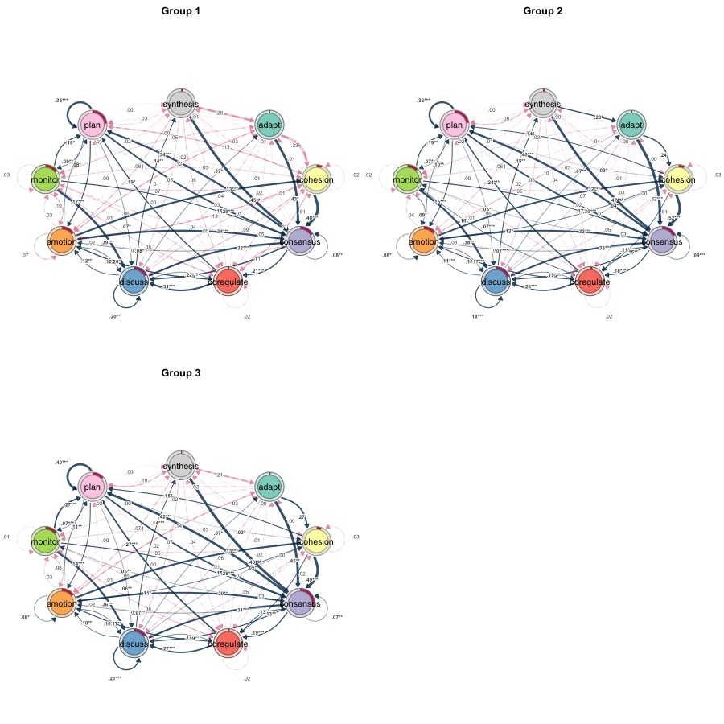

```r
layout(matrix(1:4, byrow = TRUE, ncol = 2))
plot(cluster_boot)
```

### Centrality measures

Centrality measures can be computed for each cluster to identify which states play central roles in each group’s transition dynamics.

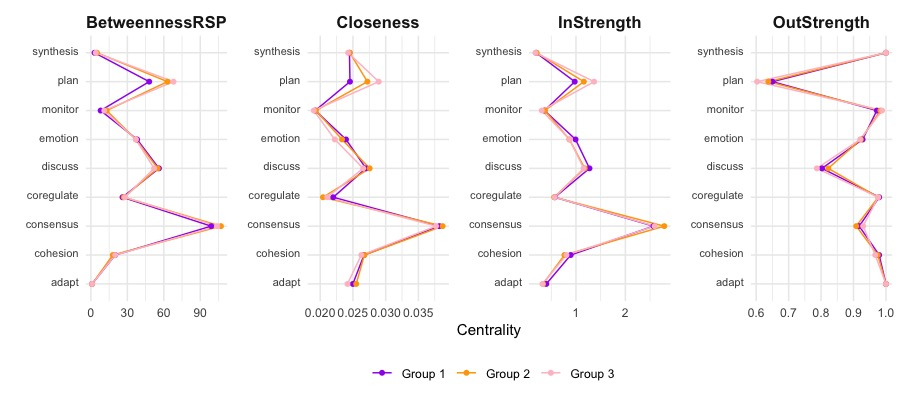

```r
centrality_measures <- c(
  "BetweennessRSP",
  "Closeness",
  "InStrength",
  "OutStrength"
)
centralities_per_cluster <- centralities(
  tna_model_clus,
  measures = centrality_measures
)
plot(
  centralities_per_cluster, ncol = 4,
  colors = c("purple", "orange", "pink")
)
```

### Subsequence comparison across clusters

Finally, we can compare subsequence frequencies across the clusters, just as we did for the pre-existing groups above.

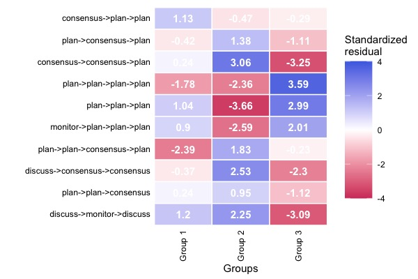

```r
subsequence_comparison  <- compare_sequences(tna_model_clus, sub = 3:5, min_freq = 5, adjust = "fdr")
plot(subsequence_comparison, cells = TRUE)
```

## More tutorials

**Package articles** · [sonsoles.me/tna](https://sonsoles.me/tna/)

- [Getting started with tna](https://sonsoles.me/tna/articles/tna.html) — build, plot, and summarize a transition network
- [Preparing data](https://sonsoles.me/tna/articles/prepare_data.html) — turn event logs into sequences with `prepare_data()`
- [A showcase of the main functions](https://sonsoles.me/tna/articles/complete_tutorial.html) — models, centralities, communities, and validation
- [Grouped sequence data](https://sonsoles.me/tna/articles/grouped_sequences.html) — build and compare networks of groups
- [Cliques and communities](https://sonsoles.me/tna/articles/communities_and_cliques.html) — find the densely connected states
- [Frequency-based TNA](https://sonsoles.me/tna/articles/ftna.html) — model transition counts instead of probabilities
- [Attention TNA](https://sonsoles.me/tna/articles/atna.html) — accumulate transitions across temporal distances
- [Validating a transition network](https://sonsoles.me/tna/articles/model-validation.html) — Markov order, bootstrap, case-dropping, reliability, and permutation tests
- [Function reference sheet](https://sonsoles.me/tna/articles/new-docs.html) — every function with its arguments and an example

**Tutorials** · [sonsoles.me](https://sonsoles.me/)

- [A comprehensive TNA tutorial](https://sonsoles.me/posts/tna-tutorial/) — an updated walkthrough of transition network analysis
- [Data preparation](https://sonsoles.me/posts/tna-data/) — from raw event data to sequences
- [Comparing models](https://sonsoles.me/posts/tna-compare/) — network comparison of TNA models
- [Clustering](https://sonsoles.me/posts/tna-clustering/) — discover and analyze clusters of sequences
- [Group analysis](https://sonsoles.me/posts/tna-group/) — permutation tests, bootstrapping, and clusters

**Book chapters** · *Advanced Learning Analytics Methods*

- [Mapping relational dynamics with TNA](https://lamethods.org/book2/chapters/ch15-tna/ch15-tna.html) — a primer and tutorial
- [Frequency transition network analysis](https://lamethods.org/book2/chapters/ch16-ftna/ch16-ftna.html) — a primer and tutorial on FTNA
- [Mining patterns and clusters with TNA](https://lamethods.org/book2/chapters/ch17-tna-clusters/ch17-tna-clusters.html) — a heterogeneity approach

**Dynalytics** · [dynasite.org](https://dynasite.org/)

- [Package sites](https://pak.dynasite.org/) — documentation of the R packages of the Dynalytics framework
- [Tools](https://dynasite.org/#/tools) — interactive web apps, jamovi, and Python
- [CarmNotes](https://dynasite.org/carmnotes) — single-file notebooks that run the analyses in the browser, even offline
- [Selected articles](https://dynasite.org/#/papers) — publications on the framework and its methods